# TEST 2. BIRD MOVEMENT ANALYSIS

Evelyn Cruz

2026-08-28

## 1. Introduction

This analysis investigates bird movement patterns in relation to time of day, flight altitude, and tidal conditions. The workflow quantifies hourly movement rates and flight altitude, compares bird activity between day and night, and evaluates the relationship between movement patterns and the timing and height of the next high tide. Descriptive statistics, non-parametric comparisons, and Spearman correlations are used to characterize temporal and environmental variation in bird movements.

## 2. Packages

```r
library(dplyr)
```

```r
library(ggplot2)
library(lubridate)
library(scales)
```

## 3. Preparing Bird Track Data

The datasets were uploaded to the R environment and inspected before analysis

```r
load("data/bird_track.rda")
names('bird_track.rda')
```

```r
load("data/tidepeak.rda")
names('tidepeak.rda')
```

The bird tracking data were prepared by converting the recorded date and time information to POSIXct format

```r
bird_track <- bird_track %>%
  mutate(date_l = as.POSIXct(date_l))
```

## 4. Classification of Day and Night

Bird records were classified into day and night periods based on the recorded hour. Records between 06:00 and 18:00 were classified as daytime, while the remaining records were classified as nighttime

```r
# Creating day and night periods
bird_track <- bird_track %>%
  mutate(hour = hour(date_l),
    period = ifelse(hour >= 6 & hour < 18,"Day","Night"))
```

# Question 1. Describe the number of bird movements/hour

## 5. MOVEMENTS PER HOUR

Counting movements by hour

```r
bird_hourly <- bird_track %>%
  mutate(hour_date = floor_date(date_l,unit = "hour")) %>%
  group_by(hour_date) %>%
  summarise(n_movements = n(),
    mean_altitude_m = mean(altm,na.rm = TRUE),
    .groups = "drop")
```

## DESCRIPTIVE STATISTICS - MOVEMENTS

Calculating movement statistics

```r
summary_movements <- bird_hourly %>%
  summarise(mean = mean(n_movements, na.rm = TRUE),
    median = median(n_movements, na.rm = TRUE),
    sd = sd(n_movements, na.rm = TRUE),
    min = min(n_movements, na.rm = TRUE),
    max = max(n_movements, na.rm = TRUE))

summary_movements
```

```
## # A tibble: 1 × 5
##    mean median    sd   min   max
##   <dbl>  <int> <dbl> <int> <int>
## 1 4182.   2583 6632.     6 28576
```

## MOVEMENTS PER HOUR - PLOT

Plotting movements per hour

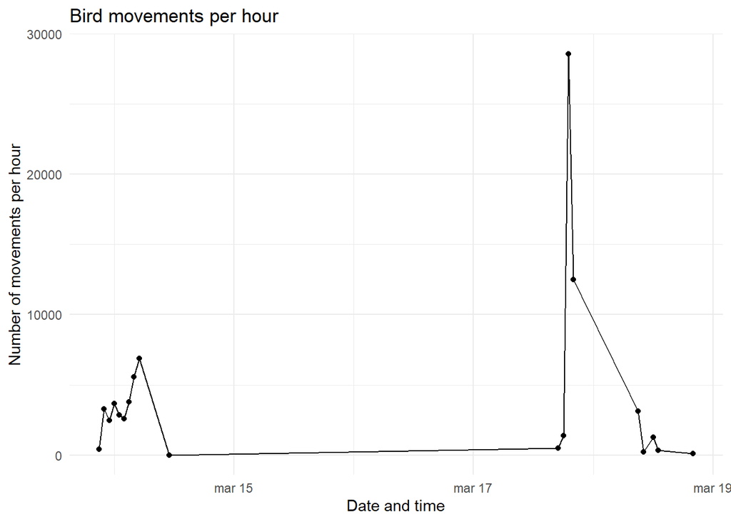

```r
ggplot(bird_hourly,
  aes(x = hour_date,
    y = n_movements)) +
  geom_line() +
  geom_point() +
  labs(title = "Bird movements per hour",
    x = "Date and time",
    y = "Number of movements per hour"
  ) +
  theme_minimal()
```

Figure 1. Chronological series of hourly bird movements. The line-and-point plot illustrates the temporal fluctuation of flight intensity across the monitoring period.

# Question 2. Describe mean flight height/hour

## 6. MEAN FLIGHT ALTITUDE PER HOUR

Calculating altitude statistics

```r
summary_altitude <- bird_hourly %>%
  summarise(mean = mean(mean_altitude_m, na.rm = TRUE),
    median = median(mean_altitude_m, na.rm = TRUE),
    sd = sd(mean_altitude_m, na.rm = TRUE),
    min = min(mean_altitude_m, na.rm = TRUE),
    max = max(mean_altitude_m, na.rm = TRUE))

summary_altitude
```

```
## # A tibble: 1 × 5
##    mean median    sd   min   max
##   <dbl>  <dbl> <dbl> <dbl> <dbl>
## 1  179.   157.  51.0  116.  283.
```

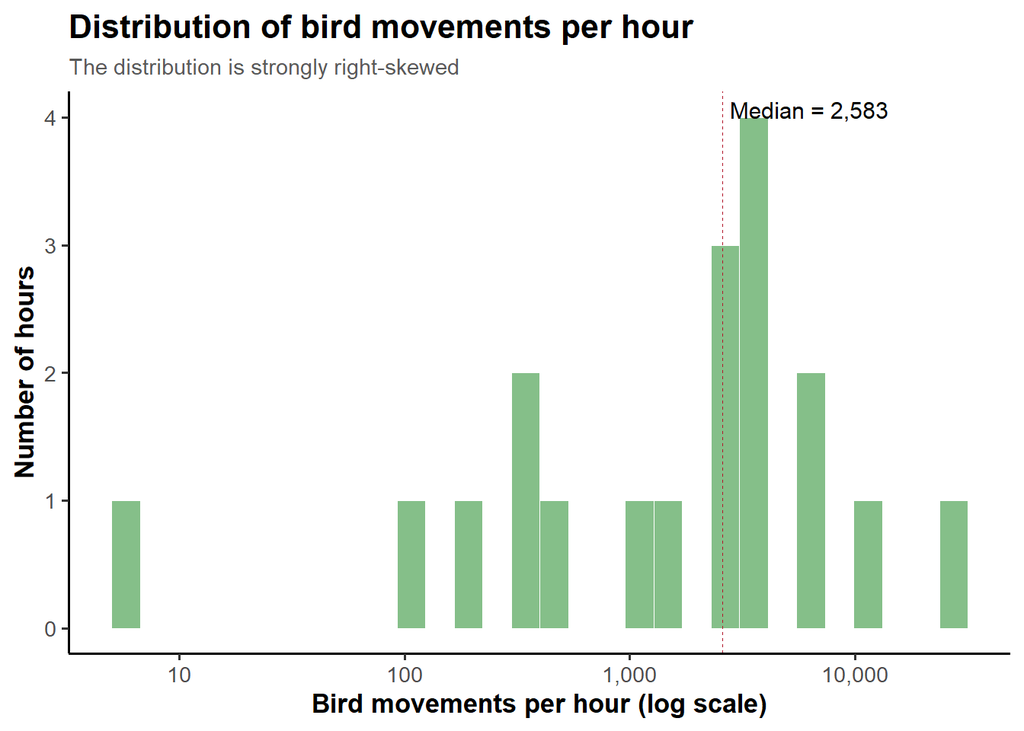

```r
plot_movements <- ggplot(bird_hourly,
  aes(x = n_movements)) +
  geom_histogram(bins = 30,
    fill = "#78b87c",
    color = "white",
    linewidth = 0.3,
    alpha = 0.9) +
  geom_vline(xintercept = median(bird_hourly$n_movements,
      na.rm = TRUE),
    color = "#B2182B",
    linetype = "dashed",
    linewidth = 0.25) +
  annotate("text",
    x = median(bird_hourly$n_movements,
      na.rm = TRUE),
    y = Inf,
    label = "Median = 2,583",
    vjust = 1.5,
    hjust = -0.05,
    size = 4) +
  scale_x_log10(labels = scales::comma) +
  labs(title = "Distribution of bird movements per hour",
    subtitle = "The distribution is strongly right-skewed",
    x = "Bird movements per hour (log scale)",
    y = "Number of hours") +
  theme_classic(base_size = 13) +
  theme(plot.title = element_text(face = "bold",
      size = 16),
    plot.subtitle = element_text(size = 11,
      color = "grey35"),
    axis.title = element_text(face = "bold"))

print(plot_movements)
```

Figure 2. Frequency distribution of hourly bird movements.

# Question 3. Are there any differences between mean number of bird movements/hour if you distinguish day and night periods?

## 7. DAY VS NIGHT - MOVEMENTS

Calculating movements by period

```r
bird_period <- bird_track %>%
  mutate(hour_date = floor_date(date_l,unit = "hour")) %>%
  group_by(hour_date,
    period) %>%
  summarise(n_movements = n(),
    mean_altitude_m = mean(altm,na.rm = TRUE),
    .groups = "drop")
```

# Question 4. Are there any differences between mean flight altitude/hour if you distinguish day and night periods?

## 8. MOVEMENTS: DAY VS NIGHT

Comparing movements between periods

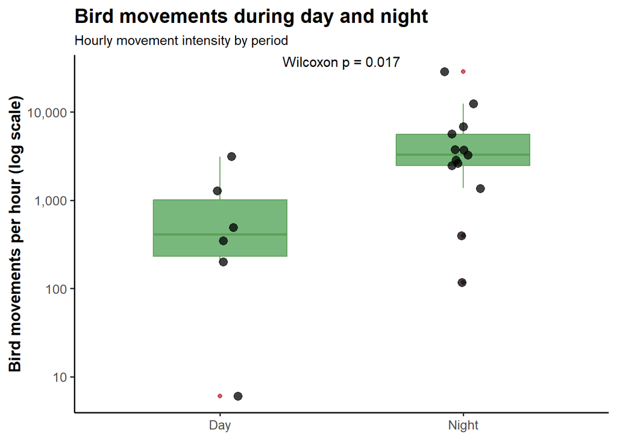

```r
plot_day_night_movements <- ggplot(bird_period,
  aes(x = period,
    y = n_movements)) +
  geom_boxplot(width = 0.55,
    fill = "#78b87c",
    color = "#5ea059",
    outlier.color = "#B2182B",
    outlier.alpha = 0.7) +
    geom_jitter(width = 0.08,
    size = 3, alpha = 0.75) +
    scale_y_log10(labels = scales::comma) +
    annotate("text",x = 1.5,
    y = max(bird_period$n_movements, na.rm = TRUE),
    label = "Wilcoxon p = 0.017",vjust = -0.5,size = 4) +
    labs(title = "Bird movements during day and night",
    subtitle = "Hourly movement intensity by period",
    x = NULL, y = "Bird movements per hour (log scale)") +
    theme_classic(base_size = 13) +
    theme(plot.title = element_text(
      face = "bold", size = 16),
    plot.subtitle = element_text(size = 11),
    axis.title = element_text(face = "bold"))

print(plot_day_night_movements)
```

Figure 3. Diurnal comparison of hourly bird movement rates, showing the contrast in flight activity between daytime and nighttime periods.

## STATISTICAL TEST - MOVEMENTS

Testing differences in movements

```r
wilcox_movements <- wilcox.test(
  n_movements ~ period,
  data = bird_period)

wilcox_movements
```

```
##
##  Wilcoxon rank sum exact test
##
## data:  n_movements by period
## W = 12, p-value = 0.01673
## alternative hypothesis: true location shift is not equal to 0
```

## 8. DAY VS NIGHT - FLIGHT ALTITUDE

Comparing flight altitude between periods

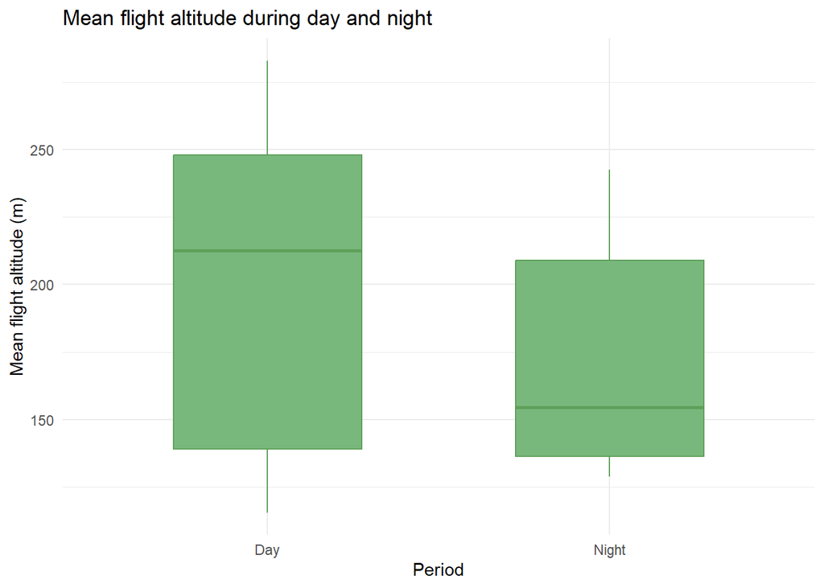

```r
plot_day_night <-ggplot(bird_period,
  aes(x = period,
    y = mean_altitude_m)) +
  geom_boxplot(width = 0.55,
    fill = "#78b87c",
    color = "#5ea059",
    outlier.color = "#B2182B",
    outlier.alpha = 0.7) +
  labs(title = "Mean flight altitude during day and night",
    x = "Period",
    y = "Mean flight altitude (m)") +
  theme_minimal()
print(plot_day_night)
```

Figure 4: Comparison of hourly mean bird flight altitude between day and night periods.

## STATISTICAL TEST - ALTITUDE

Testing differences in altitude

```r
wilcox_altitude <- wilcox.test(mean_altitude_m ~ period,
  data = bird_period)

wilcox_altitude
```

```
##
##  Wilcoxon rank sum exact test
##
## data:  mean_altitude_m by period
## W = 47, p-value = 0.5214
## alternative hypothesis: true location shift is not equal to 0
```

```r
# Summary by period
bird_period %>%
  group_by(period) %>%
  summarise(mean_movements = mean(n_movements),
    median_movements = median(n_movements),
    sd_movements = sd(n_movements),
    n_hours = n())
```

```
## # A tibble: 2 × 5
##   period mean_movements median_movements sd_movements n_hours
##   <chr>           <dbl>            <dbl>        <dbl>   <int>
## 1 Day              905.              417        1166.       6
## 2 Night           5694.             3290        7587.      13
```

```r
# Checking tidal data
str(tidepeak)
```

```
## Classes 'data.table' and 'data.frame':   2825 obs. of  4 variables:
##  $ data   : POSIXct, format: "2020-01-01 00:27:00" "2020-01-01 07:00:00" ...
##  $ mare   : chr  "Baixa-Mar" "Preia-Mar" "Baixa-Mar" "Preia-Mar" ...
##  $ altura : num  1.5 3.44 1.45 3.15 1.64 3.3 1.57 3.06 1.75 3.18 ...
##  $ dateref: POSIXct, format: "2020-01-01 00:27:00" "2020-01-01 07:00:00" ...
##  - attr(*, "problems")= tibble [1,423 × 5] (S3: tbl_df/tbl/data.frame)
##   ..$ row     : int [1:1423] 2 3 4 5 6 7 8 9 10 11 ...
##   ..$ col     : chr [1:1423] NA NA NA NA ...
##   ..$ expected: chr [1:1423] "6 columns" "6 columns" "6 columns" "6 columns" ...
##   ..$ actual  : chr [1:1423] "7 columns" "3 columns" "9 columns" "14 columns" ...
##   ..$ file    : chr [1:1423] "'https://webpages.ciencias.ulisboa.pt/~cmantunes/hidrografia/LisboaFCUL2020.TXT'" "'https://webpages.ciencias.ulisboa.pt/~cmantunes/hidrografia/LisboaFCUL2020.TXT'" "'https://webpages.ciencias.ulisboa.pt/~cmantunes/hidrografia/LisboaFCUL2020.TXT'" "'https://webpages.…
##  - attr(*, ".internal.selfref")=<externalptr>
```

```r
head(tidepeak, 10)
```

```
##                   data      mare altura             dateref
## 1  2020-01-01 00:27:00 Baixa-Mar   1.50 2020-01-01 00:27:00
## 2  2020-01-01 07:00:00 Preia-Mar   3.44 2020-01-01 07:00:00
## 3  2020-01-01 13:05:00 Baixa-Mar   1.45 2020-01-01 13:05:00
## 4  2020-01-01 19:32:00 Preia-Mar   3.15 2020-01-01 19:32:00
## 5  2020-01-02 01:15:00 Baixa-Mar   1.64 2020-01-02 01:15:00
## 6  2020-01-02 07:46:00 Preia-Mar   3.30 2020-01-02 07:46:00
## 7  2020-01-02 13:57:00 Baixa-Mar   1.57 2020-01-02 13:57:00
## 8  2020-01-02 20:22:00 Preia-Mar   3.06 2020-01-02 20:22:00
## 9  2020-01-03 02:15:00 Baixa-Mar   1.75 2020-01-03 02:15:00
## 10 2020-01-03 08:40:00 Preia-Mar   3.18 2020-01-03 08:40:00
```

```r
summary(tidepeak)
```

```
##       data                            mare               altura
##  Min.   :2020-01-01 00:27:00.00   Length:2825        Min.   :0.350
##  1st Qu.:2020-07-01 17:53:00.00   Class :character   1st Qu.:1.160
##  Median :2020-12-31 09:43:00.00   Mode  :character   Median :2.030
##  Mean   :2020-12-31 10:05:58.04                      Mean   :2.378
##  3rd Qu.:2021-07-02 02:49:00.00                      3rd Qu.:3.590
##  Max.   :2021-12-31 19:00:00.00                      Max.   :4.430
##     dateref
##  Min.   :2020-01-01 00:27:00.00
##  1st Qu.:2020-07-01 17:53:00.00
##  Median :2020-12-31 09:43:00.00
##  Mean   :2020-12-31 10:05:58.04
##  3rd Qu.:2021-07-02 02:49:00.00
##  Max.   :2021-12-31 19:00:00.00
```

# CHALLENGE: Describe the pattern of bird movement in relation to tide height and distance to next high tide

## 1. PACKAGES

```r
library(dplyr)
library(ggplot2)
library(lubridate)
library(scales)
```

## 2. PREPARE DATE-TIME VARIABLES

Converting date and time

```r
bird_track$date_l <- as.POSIXct(
  bird_track$date_l)
tidepeak$data <- as.POSIXct(
  tidepeak$data)
```

```r
# Selecting high tide records
tide_high <- tidepeak %>%
  filter(mare == "Preia-Mar") %>%
  arrange(data)
```

```r
# Finding the next high tide
bird_tide <- bird_track %>%
  arrange(date_l)

next_index <- findInterval(
  bird_tide$date_l,
  tide_high$data) + 1

next_index[next_index > nrow(tide_high)] <- NA
bird_tide$next_high_tide <- tide_high$data[next_index]
bird_tide$next_tide_height <- tide_high$altura[next_index]
```

## 3. CALCULATE TIME UNTIL NEXT HIGH TIDE

Calculating hours until high tide

```r
bird_tide$hours_to_high_tide <- as.numeric(
  difftime(bird_tide$next_high_tide,bird_tide$date_l,units = "hours"))

# Checking tidal variables
head(bird_tide[,c("date_l",
      "next_high_tide",
      "next_tide_height",
      "hours_to_high_tide")])
```

```
##                date_l      next_high_tide next_tide_height hours_to_high_tide
## 1 2021-03-13 21:51:59 2021-03-14 03:50:00             3.99           5.966944
## 2 2021-03-13 21:52:02 2021-03-14 03:50:00             3.99           5.966111
## 3 2021-03-13 21:52:02 2021-03-14 03:50:00             3.99           5.966111
## 4 2021-03-13 21:52:04 2021-03-14 03:50:00             3.99           5.965556
## 5 2021-03-13 21:52:04 2021-03-14 03:50:00             3.99           5.965556
## 6 2021-03-13 21:52:04 2021-03-14 03:50:00             3.99           5.965556
```

```r
summary(bird_tide$hours_to_high_tide)
```

```
##      Min.   1st Qu.    Median      Mean   3rd Qu.      Max.
##  0.000556  5.952778 10.029722  8.478108 10.541944 12.316667
```

## 4. AGGREGATE BIRD MOVEMENTS BY HOUR

Summarising movements and tidal conditions

```r
bird_tide_hourly <- bird_tide %>%
  mutate(date_hour = floor_date(date_l,unit = "hour")) %>%
  group_by(date_hour) %>%
  summarise(n_movements = n(),
    mean_tide_height = mean(next_tide_height,na.rm = TRUE),
    mean_hours_to_high_tide = mean(hours_to_high_tide,na.rm = TRUE),
    .groups = "drop")
```

## 5. SUMMARY

Calculating summary statistics

```r
challenge2_summary <- bird_tide_hourly %>%
  summarise(mean_movements = mean(n_movements,na.rm = TRUE),
    mean_tide_height = mean(mean_tide_height,na.rm = TRUE),
    mean_hours_to_high_tide = mean(mean_hours_to_high_tide,na.rm = TRUE),
    median_hours_to_high_tide = median(mean_hours_to_high_tide,na.rm = TRUE))

print(challenge2_summary)
```

```
## # A tibble: 1 × 4
##   mean_movements mean_tide_height mean_hours_to_high_tide median_hours_to_high…¹
##            <dbl>            <dbl>                   <dbl>                  <dbl>
## 1          4182.             3.70                    6.95                   6.95
## # ℹ abbreviated name: ¹median_hours_to_high_tide
```

## 6. BIRD MOVEMENTS × TIDE HEIGHT

Plotting movements against tide height

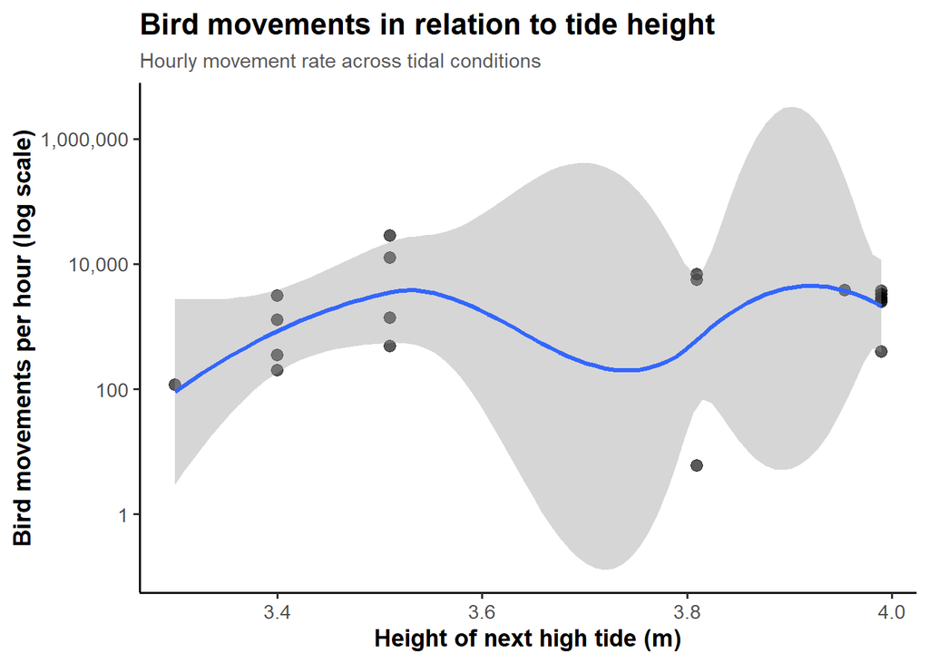

```r
plot_tide_height <- ggplot(bird_tide_hourly,
  aes(x = mean_tide_height,
    y = n_movements)) +
  geom_point(size = 2.8,
    alpha = 0.65) +
  geom_smooth(method = "loess",
    se = TRUE,
    linewidth = 1.1) +
  scale_y_log10(labels = scales::comma) +
  labs(title = "Bird movements in relation to tide height",
    subtitle = "Hourly movement rate across tidal conditions",
    x = "Height of next high tide (m)",
    y = "Bird movements per hour (log scale)") +
  theme_classic(base_size = 13) +
  theme(plot.title = element_text(face = "bold",
      size = 16),
    plot.subtitle = element_text(size = 11,
      color = "grey35"),
    axis.title = element_text(face = "bold"))

print(plot_tide_height)
```

## 7. BIRD MOVEMENTS × DISTANCE TO NEXT HIGH TIDE

Plotting movements against time to high tide

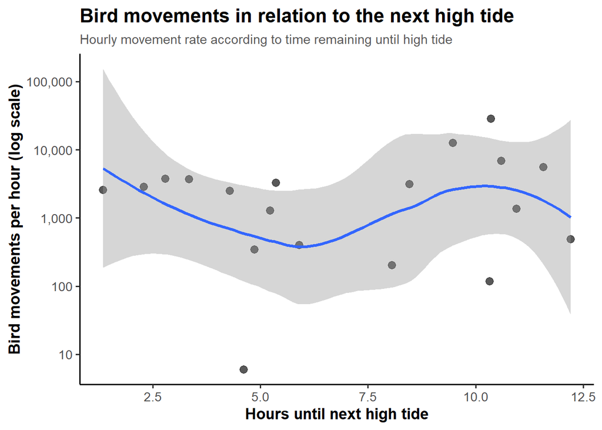

```r
plot_tide_distance <- ggplot(bird_tide_hourly,
  aes(x = mean_hours_to_high_tide,
    y = n_movements)) +
  geom_point(size = 2.8,
    alpha = 0.65) +
  geom_smooth(method = "loess",
    se = TRUE,
    linewidth = 1.1) +
  scale_y_log10(labels = scales::comma) +
  labs(title = "Bird movements in relation to the next high tide",
    subtitle = "Hourly movement rate according to time remaining until high tide",
    x = "Hours until next high tide",
    y = "Bird movements per hour (log scale)") +
  theme_classic(base_size = 13) +
  theme(plot.title = element_text(
      face = "bold",
      size = 16),
    plot.subtitle = element_text(size = 11,
      color = "grey35"),
    axis.title = element_text(face = "bold"))

print(plot_tide_distance)
```

```r
cor_tide_height <- cor.test(bird_tide_hourly$mean_tide_height,
  bird_tide_hourly$n_movements,method = "spearman",exact = FALSE)

print(cor_tide_height)
```

```
##
##  Spearman's rank correlation rho
##
## data:  bird_tide_hourly$mean_tide_height and bird_tide_hourly$n_movements
## S = 795.98, p-value = 0.2093
## alternative hypothesis: true rho is not equal to 0
## sample estimates:
##       rho
## 0.3017724
```

```r
cor_tide_distance <- cor.test(bird_tide_hourly$mean_hours_to_high_tide,
  bird_tide_hourly$n_movements, method = "spearman", exact = FALSE)

print(cor_tide_distance)
```

```
##
##  Spearman's rank correlation rho
##
## data:  bird_tide_hourly$mean_hours_to_high_tide and bird_tide_hourly$n_movements
## S = 1002, p-value = 0.6215
## alternative hypothesis: true rho is not equal to 0
## sample estimates:
##       rho
## 0.1210526
```

## 9. COMBINED TIDAL CONDITIONS

Plotting combined tidal conditions

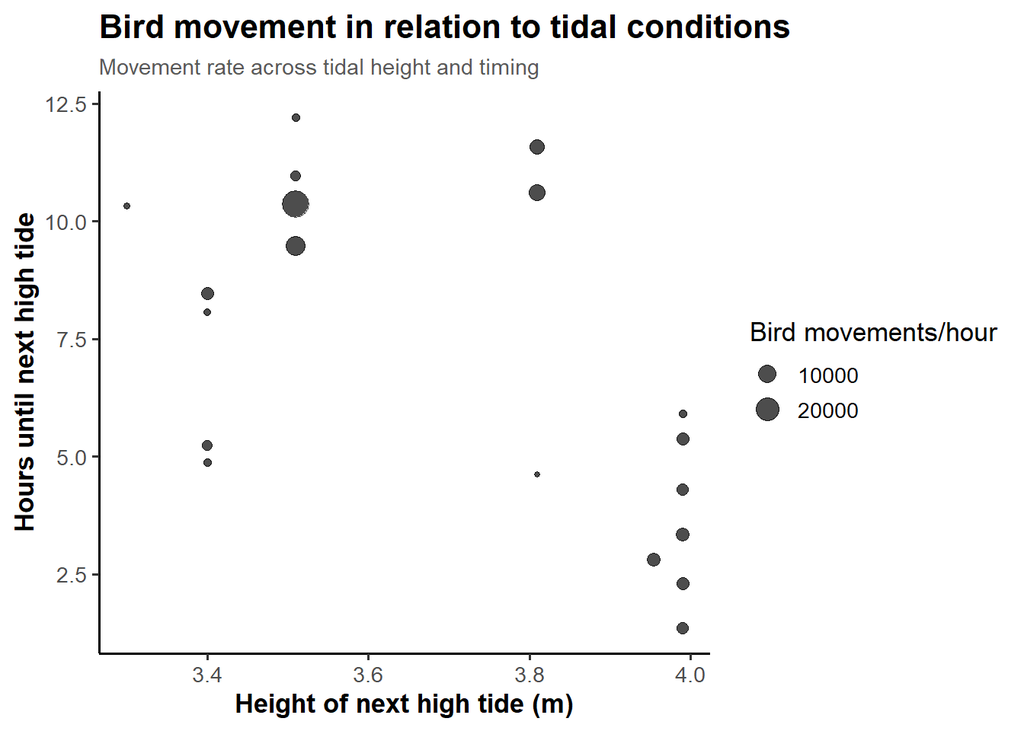

```r
plot_tide_combined <- ggplot(bird_tide_hourly,
  aes(x = mean_tide_height,
    y = mean_hours_to_high_tide,
    size = n_movements)) +
  geom_point(alpha = 0.7) +
  scale_size_continuous(name = "Bird movements/hour") +
  labs(title = "Bird movement in relation to tidal conditions",
    subtitle = "Movement rate across tidal height and timing",
    x = "Height of next high tide (m)",
    y = "Hours until next high tide") +
  theme_classic(base_size = 13) +
  theme(plot.title = element_text(face = "bold",
      size = 16),
    plot.subtitle = element_text(size = 11,
      color = "grey35"),
    axis.title = element_text(face = "bold"))

print(plot_tide_combined)
```

Figure 6. Avian movement intensity across combined tidal conditions.